# AnimationPlayer

# AnimationPlayer plays and queues handmade animations

With the `AnimationPlayer` node, you can create handcrafted animations.

When you create or select an `AnimationPlayer` node, a new editor appears in the bottom panel. It allows you to create and edit animations.

In Godot, you can animate any property you see in the *Inspector*. When an animation plays, it directly changes properties from one value to another over time.

An `AnimationPlayer` is the best tool to control lots of values changing at the same time. You can use it to animate characters, the environment, create cut-scenes, and even call functions and trigger events!

In this guide, you will learn how to:

- Set up an `AnimationPlayer` and use its key methods and signals.
- Create an animation to fade out a scene and respawn.
- Call functions within an animation.
- Create a queue of animations for an attack pattern.
- Make a simple 3D gun reload animation.
- Highlight 3D objects.

We’ll focus on the code-side of things here. To learn to use the animation editor, please watch this free intro to animation tutorial:

[figure not shown]

Contents:

- AnimationPlayer’s key features
  - Starting and stopping animations
  - Playback speed and reversing animations
  - Autoplay and looping
  - Easings and smooth animations
  - Queuing animations
  - Using sounds
- How to use an AnimationPlayer in practice
  - Creating a fade and respawn animation
  - Creating an explosion animation that triggers code
  - Creating an attack pattern with a queue
  - Creating a gun reload animation in 3D
  - Highlighting a mesh in 3D
- Your questions
  - How can I set an animation to a specific point
  - When should I use an animation player
  - Resetting my scene after playing animations
  - How to animate any value with an AnimationPlayer
  - Saving and loading animations

## AnimationPlayer’s key features

Godot’s `AnimationPlayer` packs many features. Below, we look at a few important ones to get you started using the node in your projects.

A key feature is that it can animate nearly any property of any node, including those you define in scripts. Want to animate a monster’s movement speed during an animation? You can!

You can also call any function in animations. This feature replaces “animation events” as seen in some other game engines. You can use it to emit signals, kill an object, and much more.

### Starting and stopping animations

An animation player has three main functions for playback:

- `play()` takes the name of the animation to play as a parameter. This name gets stored in the current animation property for other functions to use. If you don’t pass in a name, whatever animation is currently assigned resumes.
- `stop()` stops the current animation and has an optional reset parameter. `stop(true)` seeks to the start of the current animation after stopping.
- `is_playing()` returns a true or false value saying if an animation is currently playing.

### Playback speed and reversing animations

The `AnimationPlayer` has a `playback_speed` variable which determines how quickly animations play.

`playback_speed` defaults to `1.0`, but increasing it to `2.0` makes it play twice as fast.

The function `play_backwards()`, as the name suggests, plays the animation from the end and to the start. Under the hood, it plays the animation with a `playback_speed` of `-1.0`.

This is great for reusing animations, like fading in and out with one animation or animating a lever going one way or the other.

**Note:** The `animation_finished` signal emits when playing forward and backward. This can make it hard to distinguish between fading in and out this way in code.

### Autoplay and looping

You can set an animation to play when the scene starts automatically. To do so, click the *Autoplay On Load* button in the animation bottom panel.

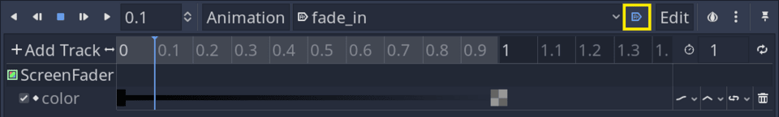

This is great for reducing unnecessary code. As a result, you rarely need to call `AnimationPlayer.play()` in a `_ready()` function.

Autoplay combines well with looping animations. Without code, you can have an animation play automatically and continuously.

For example, a coin spinning, a light flickering, or trees blowing in the wind. Note: the `animation_finished` signal doesn’t emit for looping animations because they never end.

### Easings and smooth animations

By default, animated properties change linearly. This kind of motion is rare in the real world, so it often looks unnatural.

Animation keyframes have an editable easing curve to control our animation’s spacing (how the values change over time).

This lets us give our motion acceleration and deceleration.

When you click a keyframe and select it, the *Inspector* shows its properties. There, the *Easing* property displays as an interactive curve. Click and drag it to change the transition from this keyframe to the next one.

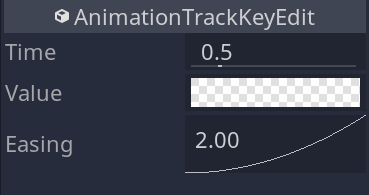

Alternatively, you can right-click to select an easing preset.

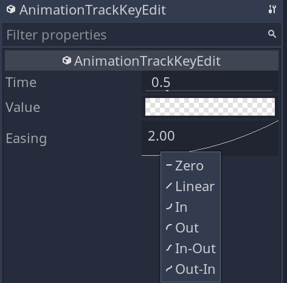

Lastly, you can double-click the curve to edit its numeric value.

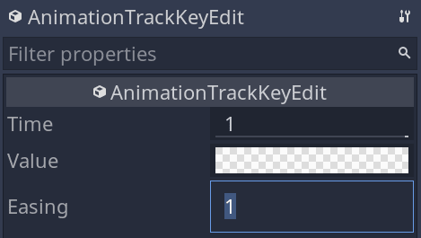

A value less than `1.0` approaches the following key quickly then slow down. An easing of more than `1.0` approaches the next key slowly then speed up.

Easings appear with property animation tracks. Instead, you can opt for a more flexible *Bezier Curve Track*.

Bezier curves give you fine-grained control over your animation transitions. To create such a track, click *Add Track -> Bezier Curve Track*.

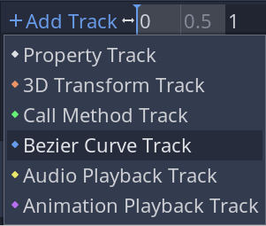

This shows the curve of values changing over time on the track itself for more precise control.

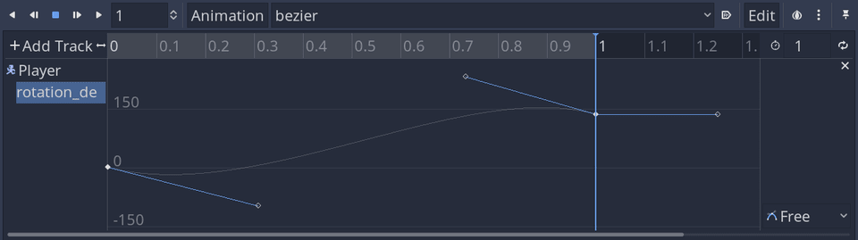

### Queuing animations

You can queue as many animations as you wish to play once the current animation finishes, and only one `animation_finished` signal emits at the very end of the whole sequence.

To add animations to the queue, call the `queue()` function alongside the animation’s name. You can remove every animation from the queue with the `clear_queue()` function.

### Using sounds

The `AnimationPlayer` makes timing playing sounds a breeze. The audio playback track shows you the audio waveform in real-time.

This is particularly helpful to see when the sound finishes and when it’s loudest.

Unfortunately, audio streams do not play well with the `play_backwards` function. The audio plays the same way regardless of the playback speed.

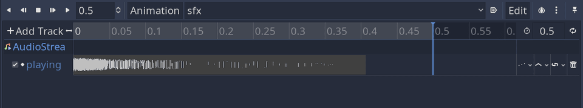

## How to use an AnimationPlayer in practice

### Creating a fade and respawn animation

To seamlessly respawn a player character, you can use a `ColorRect` to fade the whole screen to a solid color. This lets you move objects back to their starting location without the player seeing them.

Start by adding a `CanvasLayer` to your scene with a `ColorRect` filling the screen.

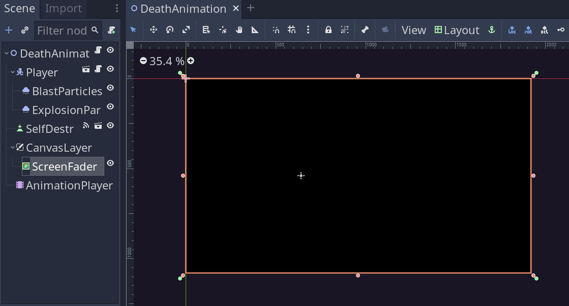

Note that by default, a `ColorRect` consumes mouse input, even if it’s transparent. If you use it to fade the screen, be sure to set its *Mouse -> Filter* to *Ignore* to prevent that.

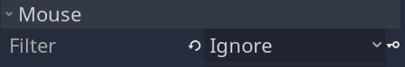

Add an `AnimationPlayer` and create a new animation. Set a keyframe where the `ColorRect`’s *Color* property is a fully transparent black at the start and another with an opaque black at the end.

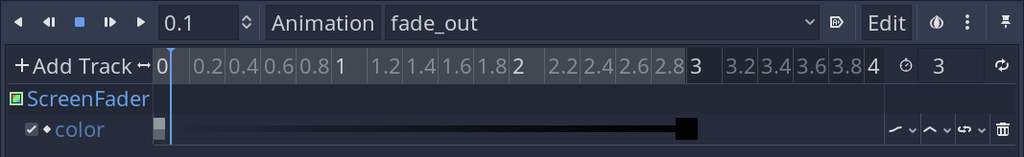

Note that you want the keyframes to use the same RGB colors when fading in and out and only animate their alpha channel. Otherwise, you may get a result that looks off.

Play the animation by calling `AnimationPlayer.play()` with its name as a parameter.

You can do that in a function and pause its execution until the animation finishes by calling `yield()`.

`AnimationPlayer` emits an `animation_finished` signal when its current animation or the animation queue ends.

```
onready var _animation_player := $AnimationPlayer


func _on_SelfDestructButton_pressed() -> void:
    # If the animation is already playing, the screen is already fading out, so
    # we avoid running the function a second time.
    if _animation_player.is_playing():
        return

    # We spawn some particles and pause the player.
    _blast_particles.restart()
    _explosion_particles.restart()
    _player.set_physics_process(false)

    _animation_player.play("fade_out")
    # Here, we wait for the animation to end.
    yield(_animation_player, "animation_finished")

    _player.set_physics_process(true)
    # This animation reloads and restarts the current scene, which works for a
    # simple respawn.
    _animation_player.play("fade_in")
```

[figure not shown]

To fade in, create a new animation and change the `ColorRect` from black to transparent.

Then click the *Autoplay On Load* button to make the animation play at the start, and the scene then fades in automatically.

Alternatively, if your fade-in and out animations have the same duration, you can create a single animation and reverse it by calling `AnimationPlayer.play_backwards()`.

### Creating an explosion animation that triggers code

An `AnimationPlayer` can call functions during an animation with a *Call Method Track*.

You can use this to trigger particles, deal damage at a specific time, or `queue_free()` a node. This is a powerful feature that can let us remove lots of unnecessary code.

This opens the door to many possibilities, including:

- Emitting particles at a player’s feet in a walking animation.
- Dealing damage and spawning bullets at specific points in an attack animation.
- Applying forces to rigid bodies.
- Deleting nodes at the end of an animation.

Before creating an explosion, we need a bomb scene. You can create it with an `Area2D` and a `CollisionShape2D` as a child. We use the area to detect the objects to damage when the bomb explodes.

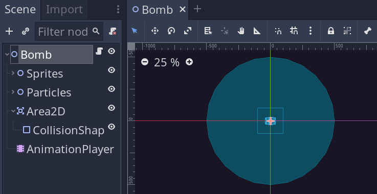

You can find an example of how to create an area to detect and damage targets in the Area2D guide.

Create a `Particles2D` node with *One Shot* enabled. You can use the *ProcessMaterial* to create an explosion effect. This process is beyond the scope of this tutorial: see the `Particles2D` guide for more information.

Now, add a script to the *Bomb* scene and make the `explode()` function we want our animation to call.

```
func explode() -> void:
    # Get all bodies in the explosions radius
    var bodies: Array = _area.get_overlapping_bodies()

    for body in bodies:
        if body.has_method("take_damage"):
            # You can add this take_damage function to whatever scenes you want
            # the explosion to damage.
            body.take_damage()
```

Add an `AnimationPlayer` to the *Bomb* scene and create an animation named “explode.” Make this play automatically with the *Autoplay On Load* button.

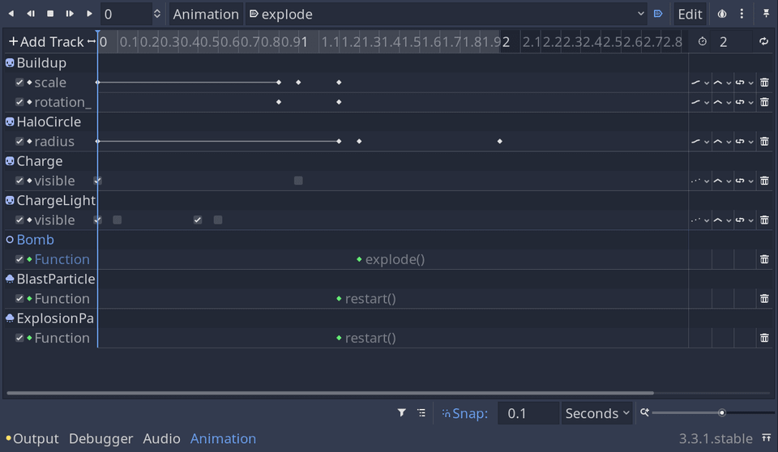

You can add a *Call Method Track* with the *Add Track* button in the top-left of the *Animation* bottom panel.

Then, select the node you want to call a method on: in our case, it’s the *Bomb*. You need to add one of these tracks for every node you want to call a function on.

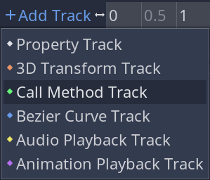

Add a key in the *Call Method Track* to call the `explode()` function when you want to do damage.

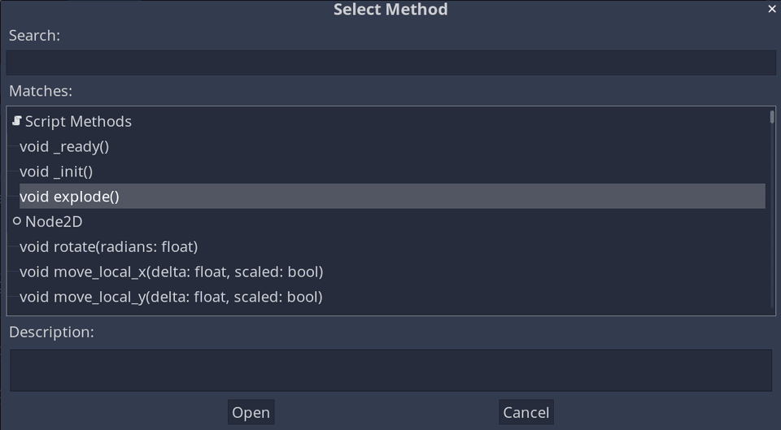

We can use the same track to free the *Bomb* in the animation. Add another key at the end of the animation which calls `queue_free()` on the bomb to delete it.

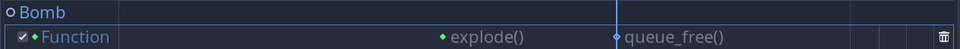

You can add as many *Call Method Track* as you want. For instance, you can add one for the `Particles2D` and have a key call its `restart()` function.

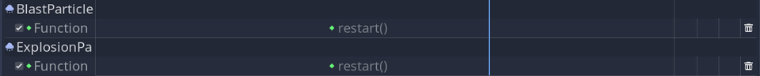

As you’ve seen, we can call both built-in functions like `Node.queue_free()` or `Particles2D.restart()`, and ones we define in a script like `explode()`.

### Creating an attack pattern with a queue

You can queue animations to play one after another.

This lets you separate long animations into manageable chunks that are easier to reuse.

With this, you can have an animation for a coin spawning followed by an idle animation of it spinning.

It also gives you convenient options like queuing a death animation to play after a character finished its “take damage” animation.

In this example, we animated a turret and designed attack patterns with its animations.

We repeat the turret’s animations a set number of times. Then, once all the attacks have finished, queue the next set of attacks.

Create a turret scene with an `AnimationPlayer` and a sprite for the turret.

We created three animations. The first two rotate the turret and call a `shoot()` function.

The “burst” animation shoots series of bullets towards the player.

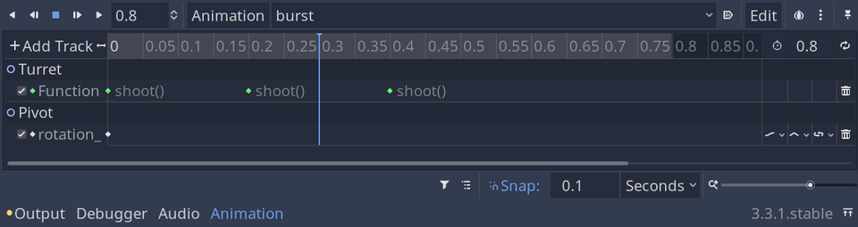

The “spray” animation shoots many bullets in an arc.

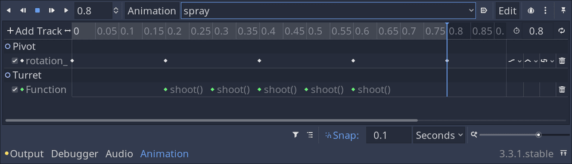

These animations can rotate the turret sprite relative to a pivot.

[figure not shown]

As a result, our animation aims relative to where the player currently is.

```
onready var _player: Player = get_node_or_null(player_path)

func _process(_delta: float) -> void:
    if not _player:
        return
    look_at(_player.global_position)
```

Finally, we have a “cooldown” animation that animates the turret’s tint, using its `modulate` property.

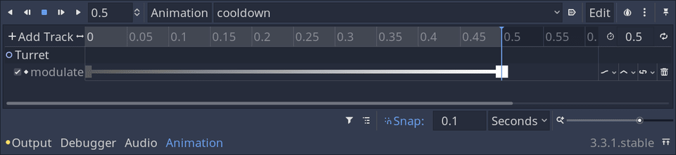

We created a dictionary with the names of our animations and how many times they should repeat.

```
const ATTACK_PATTERN_REPETITIONS := {"cooldown": 2, "burst": 3, "spray": 1}
```

Now, we can create the function that queues our attacks.

```
onready var _pattern_animator := $Pivot/AnimationPattern

func queue_shooting_pattern() -> void:
    # Get the attack animation names from the dictionary.
    var animations: Array = ATTACK_PATTERN_REPETITIONS.keys()
    # Randomize the order of our list of attacks, so the item at the front will
    # be random.
    animations.shuffle()
    var first_key: String = animations.front()

    # Find out how many times our animation should repeat
    for _x in range(ATTACK_PATTERN_REPETITIONS[first_key]):
        # Queue the animation so it will repeat for each time it's called in the
        # loop.
        _pattern_animator.queue(first_key)
```

Connect the `animation_finished` signal and have it call `queue_shooting_pattern()`. This makes our turret fire continuously.

Note: the `animation_finished` signal only emits after all queued animations finished playing.

```
func _ready() -> void:
    randomize()
    _pattern_animator.connect("animation_finished", self, "_on_AnimationPattern_animation_finished")
    queue_shooting_pattern()

# We need this callback because the signal comes with an argument but our
# queue_shooting_pattern() function takes none.
func _on_AnimationPattern_animation_finished(_anim_name: String) -> void:
    queue_shooting_pattern()
```

### Creating a gun reload animation in 3D

Navigating 3D space is significantly more complex than 2D space, but using the `AnimationPlayer` node can make your life easier.

We use an animation player to make a series of reload animations that you can combine depending on context.

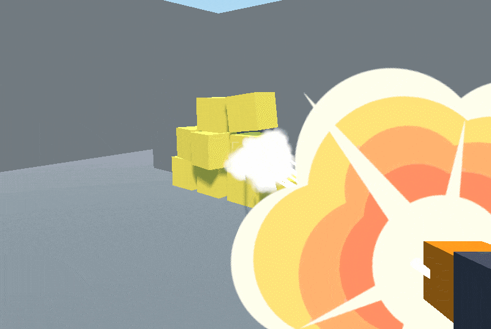

We animate:

- Firing the shotgun.
- Spinning the gun to show it’s reloading if we’re out of ammo.
- Pumping to load the next shell.

Making the animations play in this varying order is a breeze thanks to the queue function. Then the majority of our animation tracks can be 3D transform properties like *Translation*, *Rotation*, and *Scale*.

We need the script for queueing our animations. This script prepares the animations above and instances a projectile scene to fire from the weapon as the fire animation starts.

```
func shoot() -> void:
    if _animator.is_playing():
        return
    _animator.queue("Fire")
    if _current_ammo < 1:
        _animator.queue("Reload")
    _current_ammo = posmod(_current_ammo - 1, max_ammo)
    _animator.queue("Pump")
    for _index in 9:
        var pellet: RayCast = pellet_scene.instance()
        add_child(pellet)
```

Now we can focus on creating our animations. With 3D animations, it’s important to create a RESET animation to automatically return our model to a sensible default.

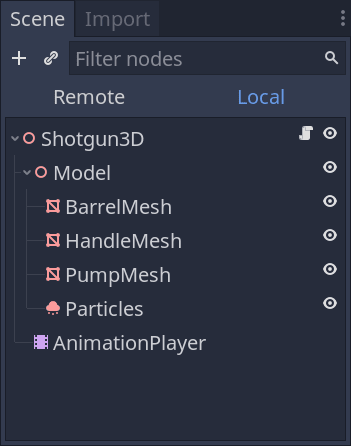

When creating an animation like this, a typical workflow is to move your nodes to the desired position in the viewport and click the keyframe buttons in the inspector for each property you want to update. Then you can move through the timeline to the next point you want to add a keyframe and repeat.

For the “Fire” animation, we restart some particles with a *Call Method Track*. We immediately move the gun back and out to the right before returning it to its starting position.

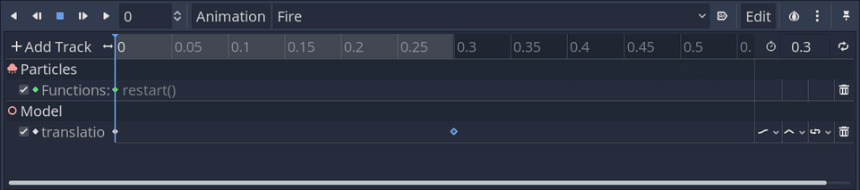

We rotate vertically `360` degrees for the “Reload” animation to end up in our starting orientation and slightly outwards while moving out and to the back before returning to the starting position.

We also increased the scale to add a bit more elasticity to the animation.

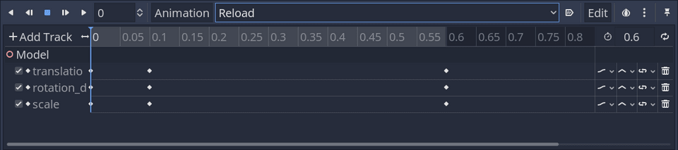

Finally, the “Pump” animation rotates the gun up and to the left, then at the peak of this angle, quickly moves the pump back before returning all the properties to their origins.

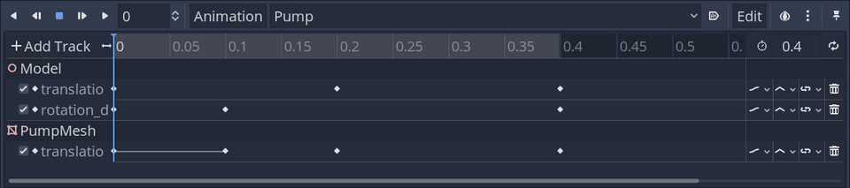

### Highlighting a mesh in 3D

Giving feedback to the player about what objects they can interact with is incredibly important for your overall game feel in any genre. It can be vital to highlight interactive things like ammo in an FPS, units you can click on in an RTS, or enemies in a hack-and-slash game.

Most simple highlights have known start and end states, so an `AnimationPlayer` is an ideal tool for the job.

In 3D, when dealing with meshes, Godot has a few helpful options for creating nodes from a mesh. This includes collision shapes, but more helpful for us: an outline `MeshInstance`.

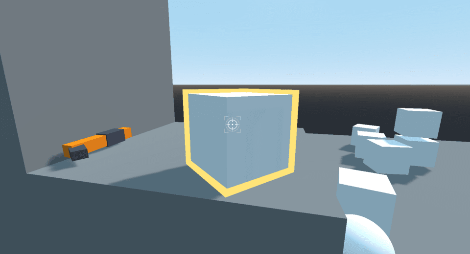

We can use a `RayCast` to make the mesh visible whenever the player views an object, using an `AnimationPlayer` to fade out the outline when the player stops looking directly at it.

Firstly, let’s cover viewing an object with a `RayCast`. Our `RayCast` should be a child of our camera and cast in the same direction. We need to check the *Enabled* property so the `RayCast` can collide with the objects we want to highlight.

Now, we can create our interactive object: a `RigidBody`, with a `MeshInstance` and a `CollisionShape`.

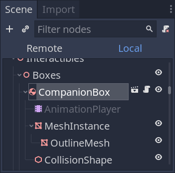

With the `MeshInstance` selected, you can click the *Mesh* button in the middle at the top of the viewport, select *Create Outline Mesh* from the dropdown and click *Create*.

You now have a child `MeshInstance` that highlights the original without even writing a shader!

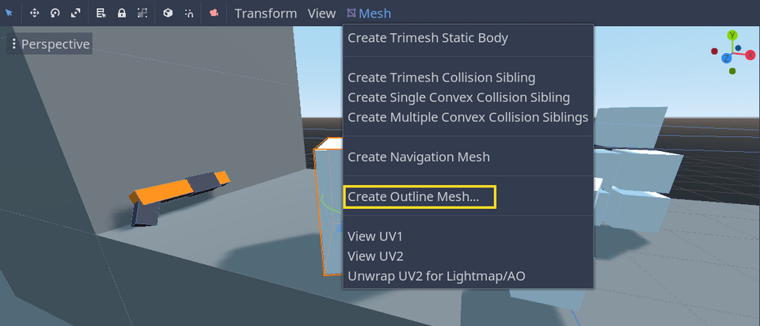

This new outline mesh needs a material for us to animate, so add a new `SpatialMaterial` in the *Material* property, and enable the *Transparent* and *Unshaded* properties. In the *Albedo* property menu, you can choose the color for your outline.

[figure not shown]

We can now create our animation to highlight the object. In an `AnimationPlayer`, we only need one animation that fades the material’s alpha channel out over a fraction of a second.

Add a keyframe with our outline color, then after a small amount of time (we chose `0.2` seconds), add a keyframe with its alpha value set to `0`. We also set the easing for these two keyframes to *In-Out* by right-clicking on the easing field.

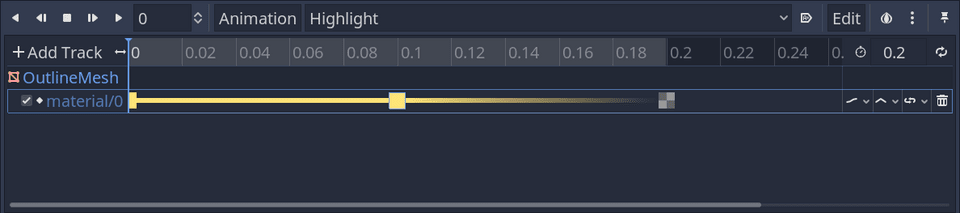

Every frame the player is looking at the object, we restart the animation. This approach avoids us needing to keep track of if the player has stopped looking at the object, as the moment the player stops, the animation can continue and fade out on its own.

Now for the code that plays the animation:

```
extends RigidBody
class_name Interactible3D

onready var _animator: AnimationPlayer = $AnimationPlayer
func highlight() -> void:
    _animator.play("Highlight")
    _animator.seek(0, true)
```

The `seek()` function call is essential as otherwise, the animation would continue from its playback position rather than restarting every time we call the function.

```
onready var _raycast: RayCast = $TiltPivot/Camera/RayCast
onready var _pickup: RemoteTransform = $TiltPivot/Camera/Pickup


func _physics_process(delta: float) -> void:
    if _raycast.get_collider() is Interactible3D:
        _pickup.remote_path = _raycast.get_collider().get_path()
        _raycast.get_collider().highlight()
```